# Regression

Dr. Liu Qizhang

18 September 2016

Regression analysis is one of the oldest and most useful statistical processes. It estimates relationships among variables, to be more precise, between a *dependent variable* (also called *response variable* or *outcome variable*) and one or more *independent variables* (also called *predictor variables* or *explanatory variables*). It results in an equation for predicting the dependent variable from the independent variables, through which we can understand how the typical value of the dependent variable changes when any one of the independent variables is varied, while the other independent variables are held constant.

Regression analysis has a wide range of applications in real life.

# Varieties of regression analysis

There are many kinds of regression analysis that may be confusing. The table below lists the typical varieties of regression analysis.

| Type of regression | Typical use |
| --- | --- |
| Simple linear | Predicting a quantitative dependent variable from a quantitative independent variable. |
| Polynomial | Predicting a quantitative depednent variable from a quantitative independent varaible, where the relationship is modeled as an *n*th order polynomial. |
| Multiple linear | Predicting a quantitative dependent variable from two or more independent variables. |
| Multilevel | Predicting a dependent variable from data that have a hierarchical structure. (For example, employees from various departments within companies) |
| Logistic | Predicting a categorical dependent variable from one or more independent variables. |
| Poisson | Predicting a dependent variable representing counts from one or more independent variables. |
| Cox proportional hazards | Predicting time to an event (death, failure, goal) from one or more independent variables |
| Time series | Modeling time-series data with correlated errors. |
| Nonlinear | Predicting a quantitative dependent variable from one or more independent variables, where the form of the model is nonlinear. |
| Nonparametric | Predicting a quantitative dependent variable from one or more independent variables, where thr form of model is derived from the data and not specified a priori. |
| Robust | Predicting a quantitative dependent variable from one or more independent variables using an approach that is resistent to the effect of influential observations. |

# Linear regression in R

In R, *lm()* is the function used for linear regression. A typical format of *lm()* function is

*lm(formula, data)*

where formula describes the model to be fit. The following table lists operators to be used in formula to make a rich range of possible models:

| Operator | Usage | Example |
| --- | --- | --- |
| ~ | Separates dependent variable on the left from the independent variable(s) on the right. | y ~ x means the model is about relationship between y and x where y is dependent variable and x is independent variable. |
| + | Links several independent variables | y ~ x1+x2+x3 means there are three independent variables x1, x2, and x3. |
| : | Indicates an interaction between independent variables. | y~x1+x2+x1:x2 means we want to predict y using x1, x2 and their interaction. |
| * | Denotes factor crossing. | y ~ x1*x2 is equivalent to y ~ x1 + x2 + x1:x2; y ~ x1*x2*x3 is equivalent to y ~ x1 + x2 + x3 + x1:x2 + x1:x3 + x2:x3 + x1:x2:x3 |
| ^ | Indicates crossing to a certain degree. | (a+b+c)^2 is identical to (a+b+c)*(a+b+c) |
| . | All variables in the data except the dependent variable. | If the data has four variables y, x1, x2, and x3, then y ~ . is identical to y ~ x1 + x2 + x3. |
| - | Removes the specific terms from the list | a*b - a is identical to b + a:b |
| -1 | Suppress the intercept. | y ~ x -1 fits a regression of y on x and forces the line through the origin. |
| I() | The operator in I() will be treated as common arithmetic operator rather than special operator as listed above. | y ~ x1 + I((x1+x2)^2) models y against x1 and (x1+x2)^2 |

After applying *lm()*, you may use the following functions to generate additional information based on the fitted model.

[output not shown]

Let’s start from a simple regression case to illustrate the use of R packages for regression analysis.

## Shoe size vs height

The night had been warm and very humid. Near closing time a small neighborhood market was robbed and the owner of the market killed. Police arrived on the scene quickly because an alarm had been sounded from the market. The suspect fled on foot through the rear door. At the rear of the store were a grassy area and a sidewalk. When police came through the rear of the store they found a clear set of wet footprints on the sidewalk. The footprints were immediately photographed and measured for size and length of stride. From this evidence alone they were able to determine approximate height, shoe size, any stride deviation and also had the ability to later match a suspect’s shoe tread with the pattern left on the sidewalk.

File “FootVSHeight.csv” stores some data collected from a group of volunteers. Let’s use simple regression to analyze it.

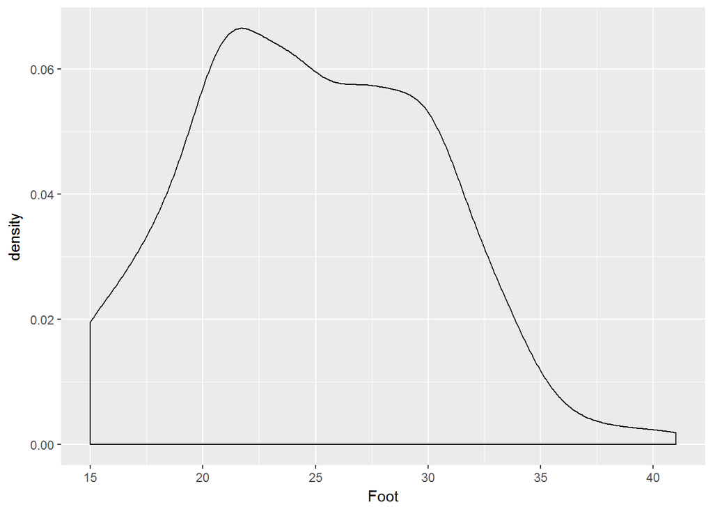

```r
data<-read.csv("FootVSHeight.csv")

#Explore data
library(ggplot2)
ggplot(data) + geom_density (aes(x=Foot))
```

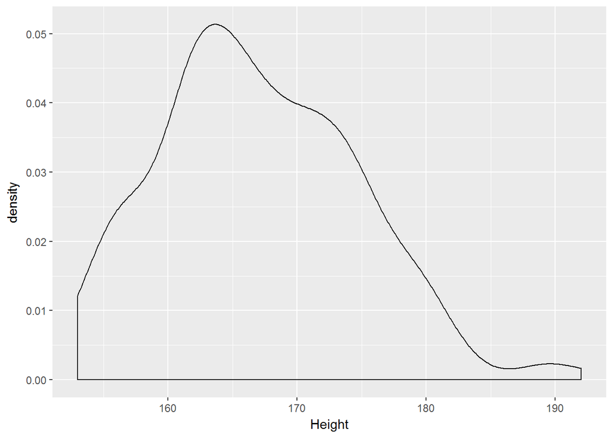

```r
ggplot(data) + geom_density (aes(x=Height)) #Both foot length and height follow approximately normal distribution
```

```r
#Fit the model using simple regression
fit<-lm(Height ~ Foot, data=data)

#Summary of the fitted model
summary(fit)
```

```
##
## Call:
## lm(formula = Height ~ Foot, data = data)
##
## Residuals:
##     Min      1Q  Median      3Q     Max
## -5.7903 -1.2453  0.2097  1.3664  5.5230
##
## Coefficients:
##              Estimate Std. Error t value Pr(>|t|)
## (Intercept) 132.69362    0.68947  192.46   <2e-16 ***
## Foot          1.38556    0.02722   50.89   <2e-16 ***
## ---
## Signif. codes:  0 '***' 0.001 '**' 0.01 '*' 0.05 '.' 0.1 ' ' 1
##
## Residual standard error: 2.05 on 198 degrees of freedom
## Multiple R-squared:  0.929,  Adjusted R-squared:  0.9286
## F-statistic:  2590 on 1 and 198 DF,  p-value: < 2.2e-16
```

```r
#Fitted data
data$Height.fitted <- fitted(fit)

#Residuals of the fitted model
data$Residual <- residuals(fit)

data
```

```
##     Foot Height Height.fitted    Residual
## 1     30    174      174.2603 -0.26031670
## 2     21    162      161.7903  0.20969290
## 3     30    177      174.2603  2.73968330
## 4     27    171      170.1036  0.89635317
## 5     30    174      174.2603 -0.26031670
## 6     21    162      161.7903  0.20969290
## 7     21    162      161.7903  0.20969290
## 8     33    177      178.4170 -1.41698656
## 9     27    171      170.1036  0.89635317
## 10    30    174      174.2603 -0.26031670
## 11    30    174      174.2603 -0.26031670
## 12    30    171      174.2603 -3.26031670
## 13    24    162      165.9470 -3.94697697
## 14    27    171      170.1036  0.89635317
```

[output cut: 186 more lines]

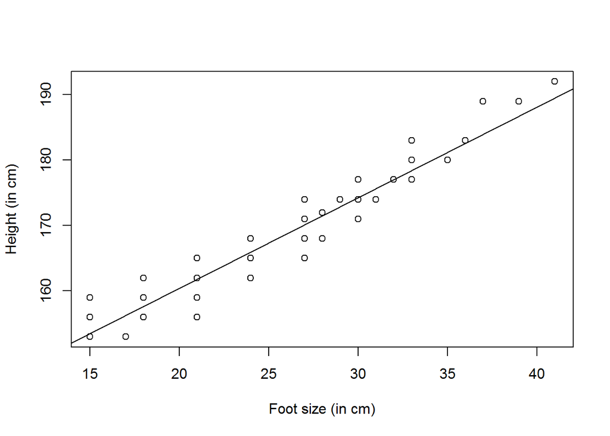

```r
plot(data$Foot, data$Height, xlab = "Foot size (in cm)", ylab="Height (in cm)")
abline(fit)
```

The slight bend in the scatter plot suggests that you might be able to improve the prediction using a regression with a quadratic term. You can fit a quadratic equation using the following R script.

```r
fit2 <- lm(Height ~ Foot + I(Foot^2), data=data)
summary(fit2)
```

```
##
## Call:
## lm(formula = Height ~ Foot + I(Foot^2), data = data)
##
## Residuals:
##     Min      1Q  Median      3Q     Max
## -5.6201 -1.7000 -0.1689  1.3000  4.3159
##
## Coefficients:
##              Estimate Std. Error t value Pr(>|t|)
## (Intercept) 1.423e+02  2.493e+00  57.094  < 2e-16 ***
## Foot        5.841e-01  2.012e-01   2.903  0.00412 **
## I(Foot^2)   1.589e-02  3.954e-03   4.018 8.36e-05 ***
## ---
## Signif. codes:  0 '***' 0.001 '**' 0.01 '*' 0.05 '.' 0.1 ' ' 1
##
## Residual standard error: 1.976 on 197 degrees of freedom
## Multiple R-squared:  0.9344, Adjusted R-squared:  0.9337
## F-statistic:  1402 on 2 and 197 DF,  p-value: < 2.2e-16
```

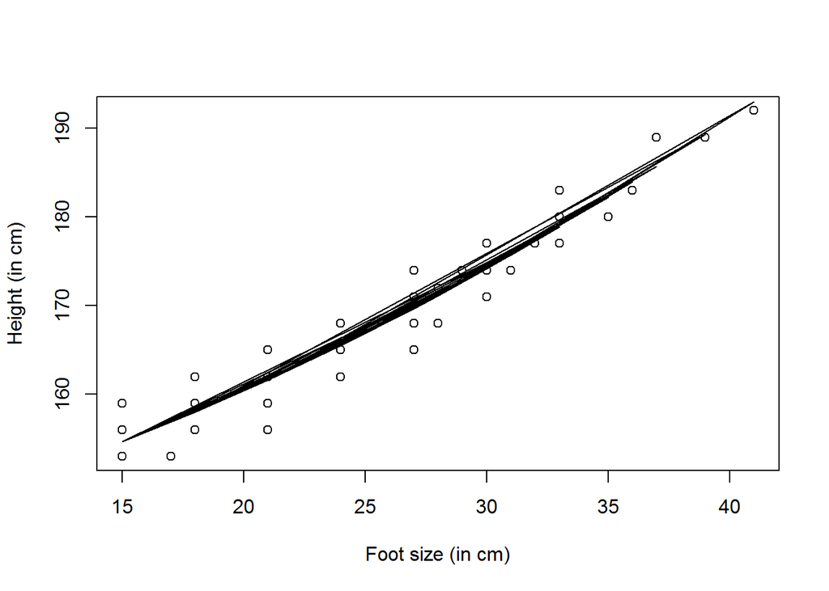

```r
plot(data$Foot, data$Height, xlab = "Foot size (in cm)", ylab="Height (in cm)")
lines(data$Foot, fitted(fit2))
```

```r
library(car)
```

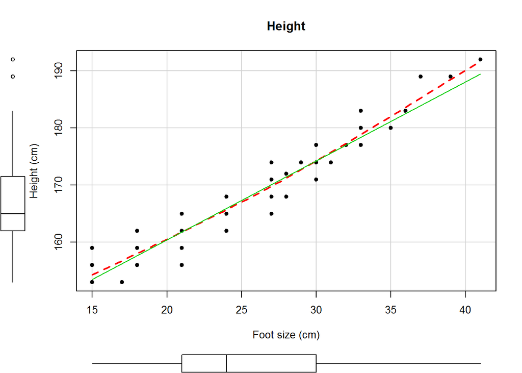

```r
scatterplot(Height~Foot, data=data,spread=FALSE,smoother.args=list(lty=2),pch=19,main="Height",
            xlab = "Foot size (cm)", ylab="Height (cm)")
```

This enhanced plot provides the scatter plot of foot size with height, box plots for each variable in their respective margin, the linear line of best fit, and a smoothed (loess) fit line. The *spread=FALSE* option suppress spread and asymmetry information. The *smoother.args=list(lty=2)* option specifies that the loess fit be rendered as a dashed line. The *pch=19* option displays points as filled circles.

## How is CEO compensation decided?

Very often, there are more than one independent variables. In this case, simple linear regression becomes multiple linear regression. We will use the CEO compensation data reported by Forbes in 2008 as the case.

```r
compensation.original <- read.csv("CEO Compensation 2008 Forbes Annotated.csv")

#Set some factor variable to numeric variable
compensation.original$Gender <- ifelse(compensation.original$Gender=="M",1,0)
compensation.original$Founder <- ifelse(compensation.original$Founder=="Yes",1,0)


#Select a subset of the data for regression analysis
compensation <- compensation.original[,c("Gender","Founder","Years.as.company.CEO","Years.with.company","Age",
                                  "Total.2008.compensation","Shares.owned....millions.")]
```

A good first step in multiple linear regression is to examin the relationship among variables two at a time. The *cor()* function provides a matrix view of the correlation among variables and the *scatterplotMatrix()* function in *car* package gives a nice scatter plot matrix to show such relationship graphically.

```r
cor(compensation)
```

```
##                               Gender    Founder Years.as.company.CEO
## Gender                    1.00000000 0.03184174           0.07792743
## Founder                   0.03184174 1.00000000           0.47230218
## Years.as.company.CEO      0.07792743 0.47230218           1.00000000
## Years.with.company        0.08918555 0.16545031           0.43105916
## Age                       0.03694338 0.09862780           0.43069401
## Total.2008.compensation           NA         NA                   NA
## Shares.owned....millions. 0.01762367 0.20328178           0.30489020
##                           Years.with.company        Age
## Gender                            0.08918555 0.03694338
## Founder                           0.16545031 0.09862780
## Years.as.company.CEO              0.43105916 0.43069401
## Years.with.company                1.00000000 0.32783191
## Age                               0.32783191 1.00000000
## Total.2008.compensation                   NA         NA
## Shares.owned....millions.         0.13086474 0.15924426
##                           Total.2008.compensation
## Gender                                         NA
## Founder                                        NA
## Years.as.company.CEO                           NA
## Years.with.company                             NA
## Age                                            NA
## Total.2008.compensation                         1
## Shares.owned....millions.                      NA
##                           Shares.owned....millions.
## Gender                                   0.01762367
## Founder                                  0.20328178
## Years.as.company.CEO                     0.30489020
## Years.with.company                       0.13086474
## Age                                      0.15924426
## Total.2008.compensation                          NA
## Shares.owned....millions.                1.00000000
```

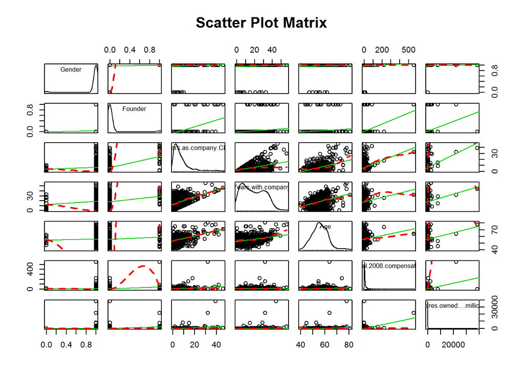

```r
library(car)
scatterplotMatrix(compensation,spread=FALSE,smoother.args=list(lty=2),main="Scatter Plot Matrix")
```

Please discuss the findings from this matrix.

Now let’s fit the model with *lm()* function.

```r
dim(compensation)
```

```
## [1] 500   7
```

```r
compensation <- compensation[complete.cases(compensation),]
dim(compensation)
```

```
## [1] 499   7
```

```r
compensation <- compensation[compensation$Total.2008.compensation>0,]

fit <- lm(Total.2008.compensation~Gender+Founder+Years.as.company.CEO
          +Years.with.company+Age+Shares.owned....millions., data=compensation)
summary(fit)
```

```
##
## Call:
## lm(formula = Total.2008.compensation ~ Gender + Founder + Years.as.company.CEO +
##     Years.with.company + Age + Shares.owned....millions., data = compensation)
##
## Residuals:
##     Min      1Q  Median      3Q     Max
## -208.00   -6.14   -3.54    0.86  411.28
##
## Coefficients:
##                             Estimate Std. Error t value Pr(>|t|)
## (Intercept)               -3.9384822 13.6987359  -0.288  0.77385
## Gender                     2.9082378  7.4275183   0.392  0.69556
## Founder                   21.3579556  7.9887777   2.673  0.00776 **
## Years.as.company.CEO       0.3080891  0.2332577   1.321  0.18718
## Years.with.company         0.0063304  0.1134920   0.056  0.95554
## Age                        0.1532891  0.2210235   0.694  0.48830
## Shares.owned....millions.  0.0047984  0.0006237   7.693 7.94e-14 ***
## ---
## Signif. codes:  0 '***' 0.001 '**' 0.01 '*' 0.05 '.' 0.1 ' ' 1
##
## Residual standard error: 27.26 on 490 degrees of freedom
## Multiple R-squared:  0.181,  Adjusted R-squared:  0.171
## F-statistic: 18.05 on 6 and 490 DF,  p-value: < 2.2e-16
```

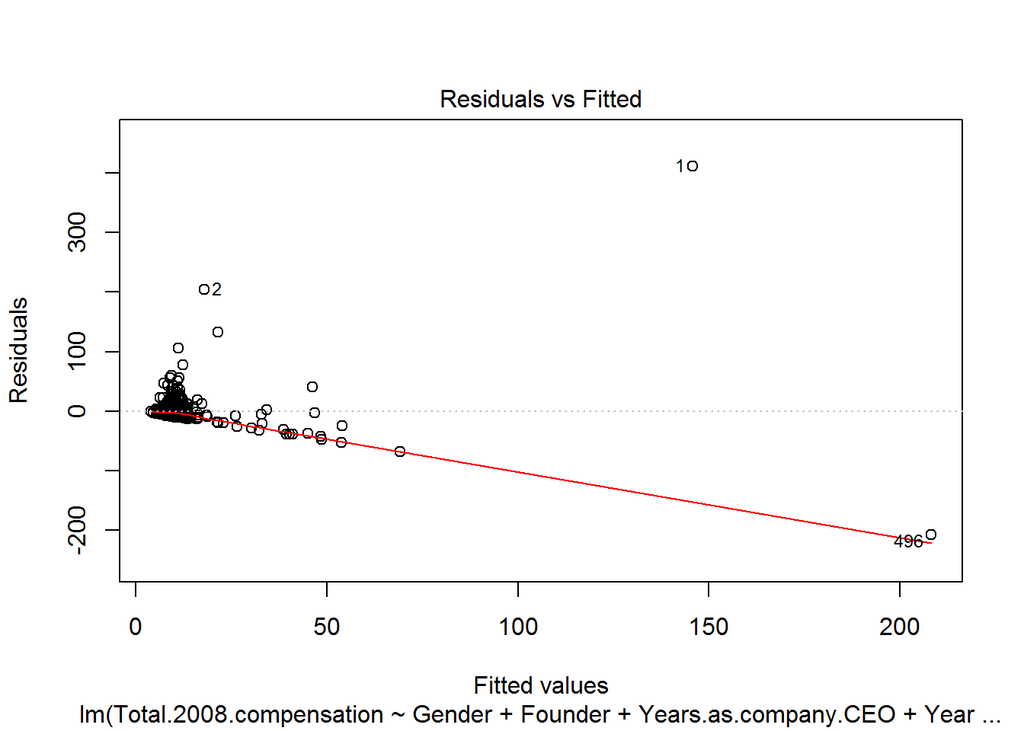

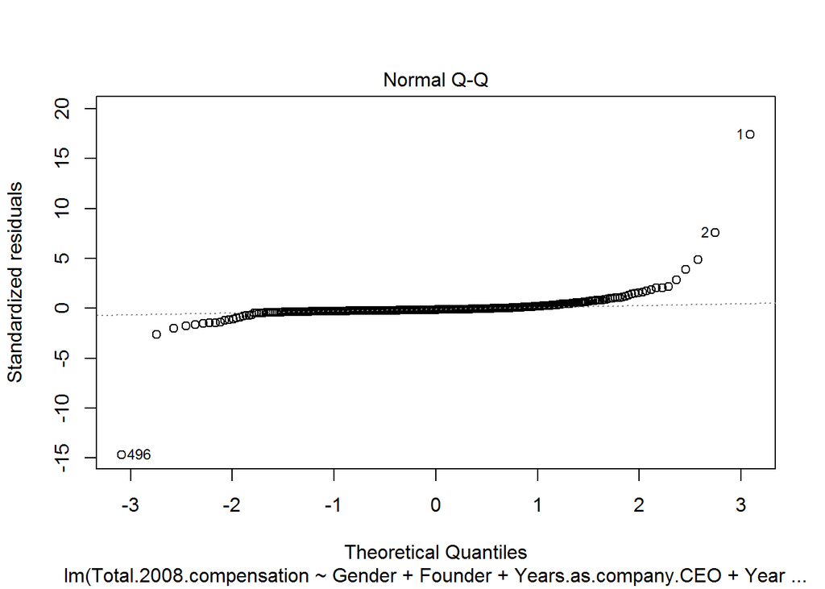

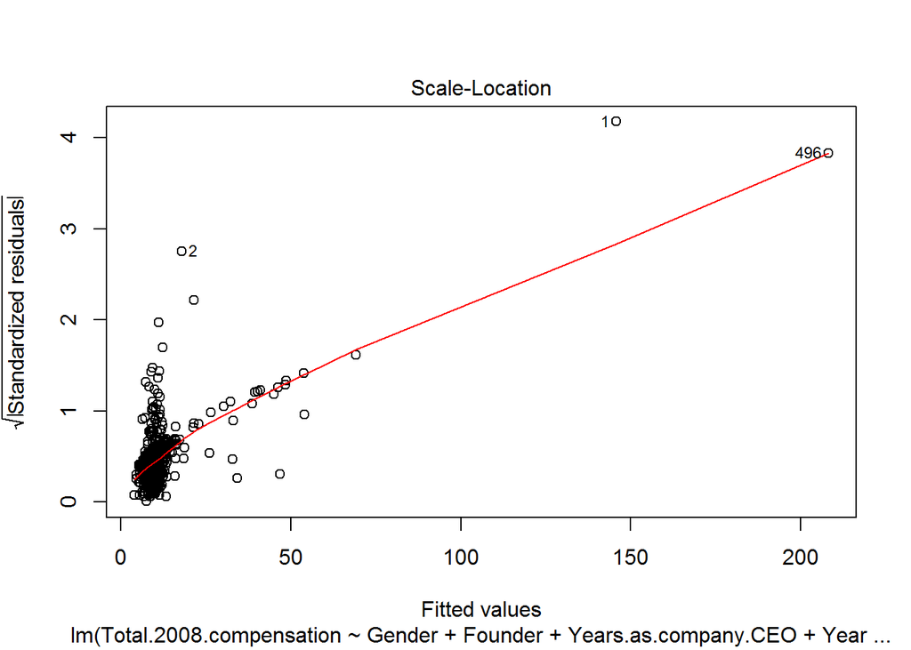

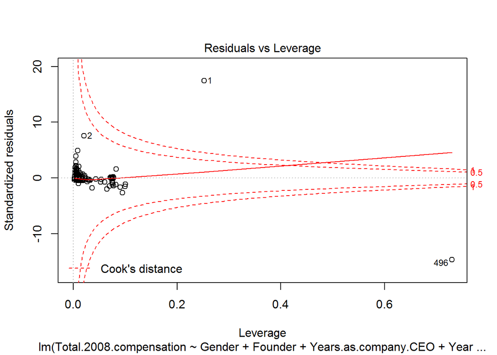

```r
#Using plot to plot the fitted model
plot(fit)
```

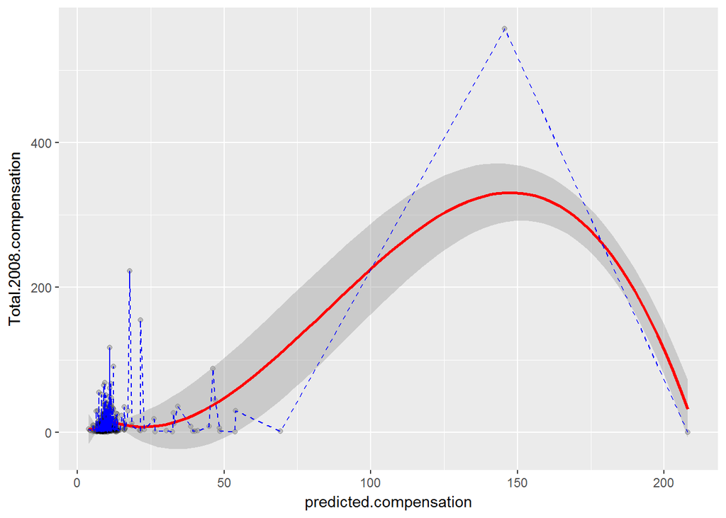

```r
#Plot fitted value against original value
compensation$predicted.compensation = predict(fit,newData=compensation)

library(ggplot2)
ggplot(data=compensation,aes(x=predicted.compensation,y=Total.2008.compensation))+geom_point(alpha=0.2,color="black") +geom_smooth(aes(x=predicted.compensation,y=Total.2008.compensation), color="red") +geom_line(aes(x=predicted.compensation,y=Total.2008.compensation),color="blue",linetype=2)
```

As we can see here, it seems whether the CEO is the founder of the company and the number of shares he owns have significant impact on the total compensation. You may try what are the factors affecting other compensation packages.

Also from the graph, we can see that there are outliers in the range of extremely large compensation and small compensation. Let’s see what if we concentrate on the middle range.

```r
compensation.middle <- compensation[compensation$Total.2008.compensation >= 1 & compensation$Total.2008.compensation  <=100,]

fit2<-lm(log(Total.2008.compensation,base=10)~Gender+Founder+Years.as.company.CEO
          +Years.with.company+Age+Shares.owned....millions., data=compensation.middle)
summary(fit2)
```

```
##
## Call:
## lm(formula = log(Total.2008.compensation, base = 10) ~ Gender +
##     Founder + Years.as.company.CEO + Years.with.company + Age +
##     Shares.owned....millions., data = compensation.middle)
##
## Residuals:
##     Min      1Q  Median      3Q     Max
## -0.9625 -0.2526 -0.0212  0.2434  1.0766
##
## Coefficients:
##                             Estimate Std. Error t value Pr(>|t|)
## (Intercept)                4.423e-01  2.065e-01   2.142   0.0327 *
## Gender                     4.039e-02  1.085e-01   0.372   0.7098
## Founder                   -1.511e-01  1.322e-01  -1.143   0.2537
## Years.as.company.CEO       1.393e-02  3.479e-03   4.002 7.29e-05 ***
## Years.with.company         1.422e-03  1.703e-03   0.835   0.4042
## Age                        3.345e-03  3.374e-03   0.992   0.3219
## Shares.owned....millions. -6.201e-05  3.508e-05  -1.768   0.0777 .
## ---
## Signif. codes:  0 '***' 0.001 '**' 0.01 '*' 0.05 '.' 0.1 ' ' 1
##
## Residual standard error: 0.3977 on 469 degrees of freedom
## Multiple R-squared:  0.07067,    Adjusted R-squared:  0.05878
## F-statistic: 5.944 on 6 and 469 DF,  p-value: 5.342e-06
```

```r
table(compensation$Industry)
```

```
## < table of extent 0 >
```

Exercise: perform regression analysis on the data with respect to individual industries.

# What matters when selling your Toyota car

In this case, we are going to use a set of data of Toyota resale cars to understand what are the most important factors affecting resale car price.

```r
#read in data
cars <- read.csv("ToyotaCorolla.csv")
cars <- cars[,c(-4)]

cor(cars)
```

```
##                 Price         Age          KM          HP    MetColor
## Price      1.00000000 -0.87659050 -0.56996016  0.31498983  0.10890475
## Age       -0.87659050  1.00000000  0.50567218 -0.15662202 -0.10814958
## KM        -0.56996016  0.50567218  1.00000000 -0.33353795 -0.08050293
## HP         0.31498983 -0.15662202 -0.33353795  1.00000000  0.05871170
## MetColor   0.10890475 -0.10814958 -0.08050293  0.05871170  1.00000000
## Automatic  0.03308069  0.03171677 -0.08185408  0.01314403 -0.01933545
## CC         0.16506697 -0.13318154  0.30215036  0.05088370  0.03492137
## Doors      0.18532555 -0.14835921 -0.03619661  0.09242450  0.08524283
## Weight     0.58119759 -0.47025318 -0.02859846  0.08961406  0.05792883
##             Automatic          CC       Doors      Weight
## Price      0.03308069  0.16506697  0.18532555  0.58119759
## Age        0.03171677 -0.13318154 -0.14835921 -0.47025318
## KM        -0.08185408  0.30215036 -0.03619661 -0.02859846
## HP         0.01314403  0.05088370  0.09242450  0.08961406
## MetColor  -0.01933545  0.03492137  0.08524283  0.05792883
## Automatic  1.00000000 -0.06932134 -0.02765382  0.05724851
## CC        -0.06932134  1.00000000  0.12676764  0.65144958
## Doors     -0.02765382  0.12676764  1.00000000  0.30261764
## Weight     0.05724851  0.65144958  0.30261764  1.00000000
```

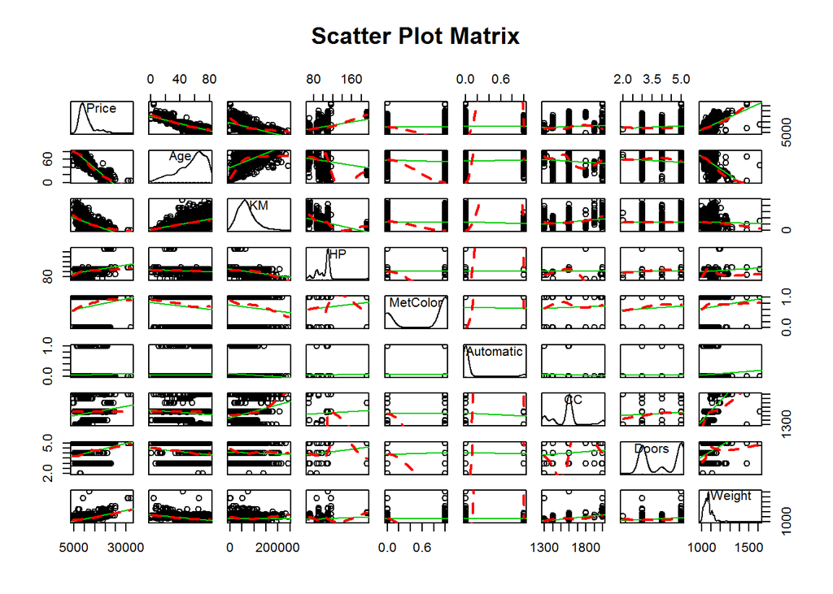

```r
scatterplotMatrix(cars,spread=FALSE,smoother.args=list(lty=2),main="Scatter Plot Matrix")
```

Exercise: Discuss the output of this script.

```r
#Fit the data with multiple regression analysis
fit <- lm(Price ~ ., data=cars)
summary(fit)
```

```
##
## Call:
## lm(formula = Price ~ ., data = cars)
##
## Residuals:
##      Min       1Q   Median       3Q      Max
## -12052.6   -765.8     -9.6    753.5   6236.4
##
## Coefficients:
##               Estimate Std. Error t value Pr(>|t|)
## (Intercept) -6.033e+03  1.005e+03  -6.005 2.42e-09 ***
## Age         -1.225e+02  2.623e+00 -46.684  < 2e-16 ***
## KM          -1.659e-02  1.293e-03 -12.829  < 2e-16 ***
## HP           3.275e+01  2.547e+00  12.860  < 2e-16 ***
## MetColor     3.654e+01  7.593e+01   0.481    0.630
## Automatic    1.942e+02  1.572e+02   1.235    0.217
## CC          -1.632e+00  2.810e-01  -5.806 7.88e-09 ***
## Doors       -5.704e+01  3.928e+01  -1.452    0.147
## Weight       2.255e+01  1.082e+00  20.845  < 2e-16 ***
## ---
## Signif. codes:  0 '***' 0.001 '**' 0.01 '*' 0.05 '.' 0.1 ' ' 1
##
## Residual standard error: 1334 on 1427 degrees of freedom
## Multiple R-squared:  0.8654, Adjusted R-squared:  0.8646
## F-statistic:  1147 on 8 and 1427 DF,  p-value: < 2.2e-16
```

Please discuss about the result.

## Regression Analysis

So far we only use *lm()* function to fit a regression model and the *summary()* function to obtain the model parameters and summary statistics. However, these function don’t tell us whether the model is appropriate, which very much depends on the degree to which you have met the statistical assumptions of the regression model.

Irregularities in the data or misspecifications of the relationships between the dependent variable and the independent variables can lead you to a model which can be very inaccurate. Let’s take a look at the output from *confint()* function.

```r
confint(fit)
```

```
##                     2.5 %        97.5 %
## (Intercept) -8.004110e+03 -4.062495e+03
## Age         -1.276178e+02 -1.173255e+02
## KM          -1.913101e-02 -1.405654e-02
## HP           2.775862e+01  3.775133e+01
## MetColor    -1.124090e+02  1.854979e+02
## Automatic   -1.142576e+02  5.026073e+02
## CC          -2.182802e+00 -1.080297e+00
## Doors       -1.340954e+02  2.001302e+01
## Weight       2.042422e+01  2.466753e+01
```

The result suggest that you can be 95% confident that [-127.6,-117.3] contains the true change in car price for one more year in car age. However, because the confidence interval for MetColor contains 0, you can conclude that a change in MetColor is unrelated to the car price. Still, we need to test the statistical assumptions underlying the model. We will introduce a few common methods in the following sections.

### Plot

There are four assumptions of regression (known by the acronym LINE):

- **Lineariry**: the relationship between variables is linear.
- **Independence of errors*: the errors be independent of one another. This assumption is particularly important when data are collected over a period of time.
- **Normality**: the errors be normally distributed at each value of the independent variables.
- **Equal variance** or **homoscedasticity**: the variance of the errors be constant for all independent variables. If there are serious departures from this assumption, you can use either data transformations or weighted least-squares methods.

The most common approach to evaluate the above assumptions in R is to apply *plot()* function. For example:

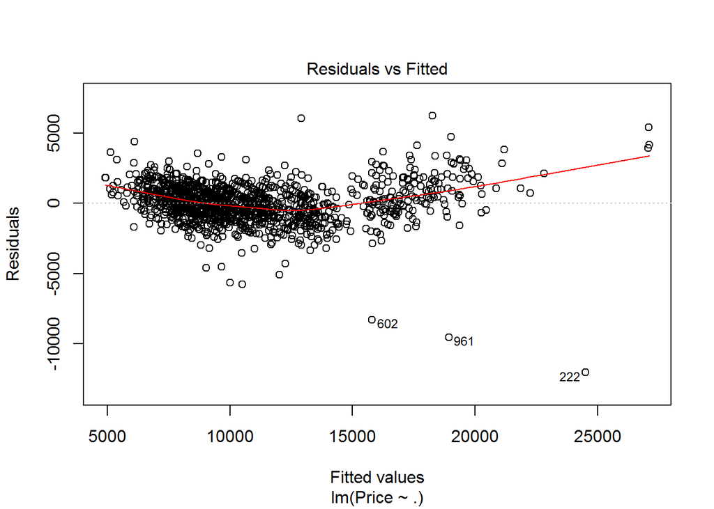

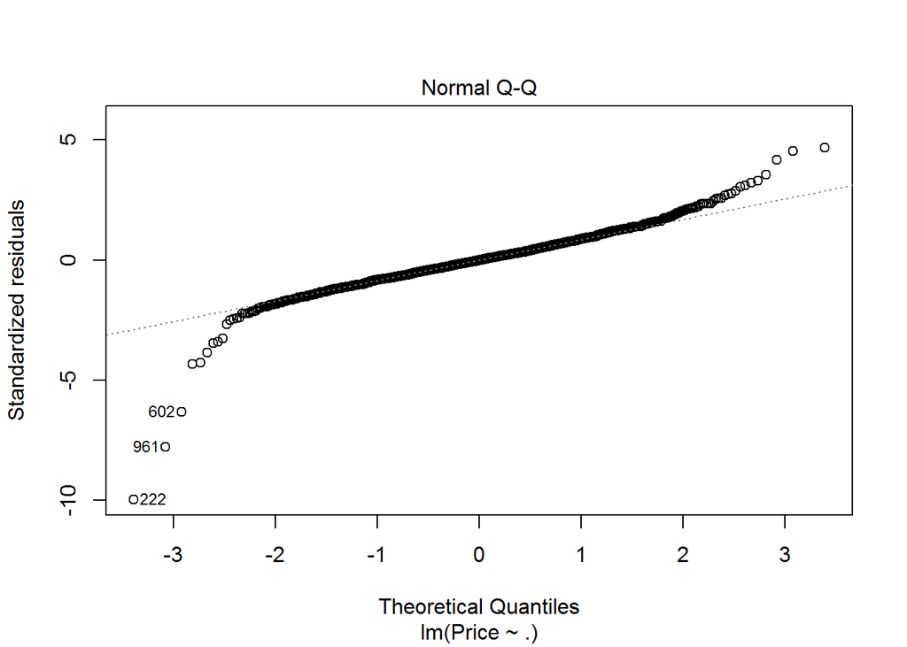

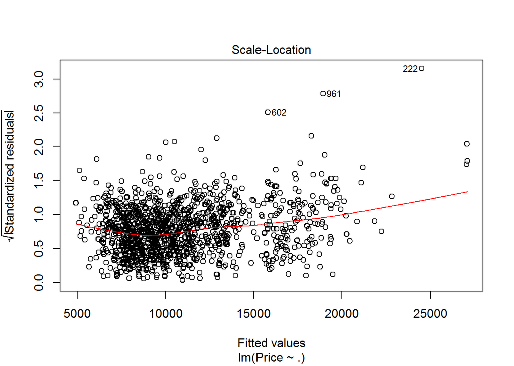

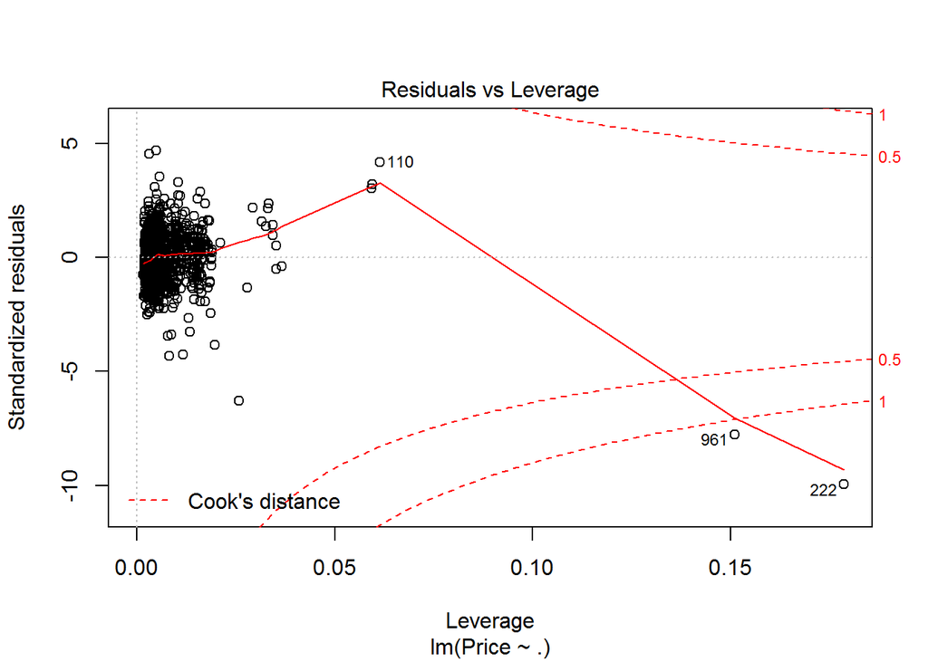

```r
plot(fit)
```

- **Linearity**: If this assumption is met, there should be no systematic relationship between the residuals and the predicted (that is, fitted) values. In other words, the residuals (eerors) should be purely random. But from “Residuals vs Fitted” graph, there seems to be a curvely pattern in the plot. It suggests that there is a non-linear relationship between Price and other factors. We may consider some non-linear model.

Reference: [Interpreting residual plots to improve your regression](http://docs.statwing.com/interpreting-residual-plots-to-improve-your-regression/)

- **Independence of errors**: We can’t really tell if the independent values are independent from these plots. Normally we have to understand how data are collected in order to tell it.
- **Normality**: the residual values should be normally distributed with a mean of 0. The Normal Q-Q plot is a probability plot of the standardized errors agains the values that would be expected under normality. If normality assumption is met, the points on this graph should fall on the straight 45-degree line. The points in this plot mostly fall in the line, but the starting and ending part fall out of the line. It shows that there are outliers at the two ends of the data range. This can be further validated by the following graph:

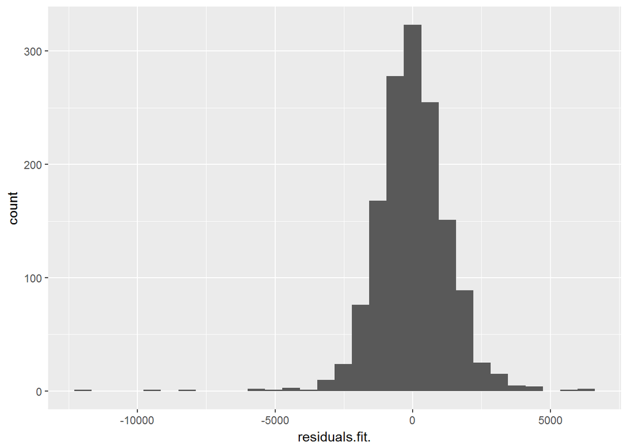

```r
res <- data.frame(residuals(fit))
ggplot(res) + geom_histogram(aes(x=residuals.fit.))
```

Reference: [Examples of Interpreting Q-Q Plot](http://emp.byui.edu/BrownD/Stats-intro/dscrptv/graphs/qq-plot_egs.htm)

- **Equal Variance**: scale-location plot gives an idea on this assumption. The plot in this case seems to be mostly ok.

Finally, the residual vs leverage graph provides informaiton about individual observations that you may wish to attend to. The graph identifies outliers, high-leverage points, and influential observations.

### car Package

The *car* package provides a suite of functions that enhance your capability to analyse the regression model. Below is the list:

| **Function** | **Purpose** |
| --- | --- |
| *qqPlot()* | Quantile comparisons plot |
| *durbinWatsonTest()* | Durbin-Watson test for autocorrelation errors |
| *crPlots()* | Component plus residual plots |
| *ncvTest()* | Score test for nonconstant error variance |
| *spreadLevelPlot()* | Spread-level plots |
| *outlierTest()* | Bonferroni outlier test |
| *avPlots()* | Added variable plots |
| *influencePlot()* | Regression influence plots |
| *scatterPlot()* | Enhanced scatter plot |
| *scatterplotMatrix()* | Enhanced scatter plot matrix |
| *vif()* | Variance inflation factors |

Let’s now use *car* package to relook at the anaylsis of the four assumptions.

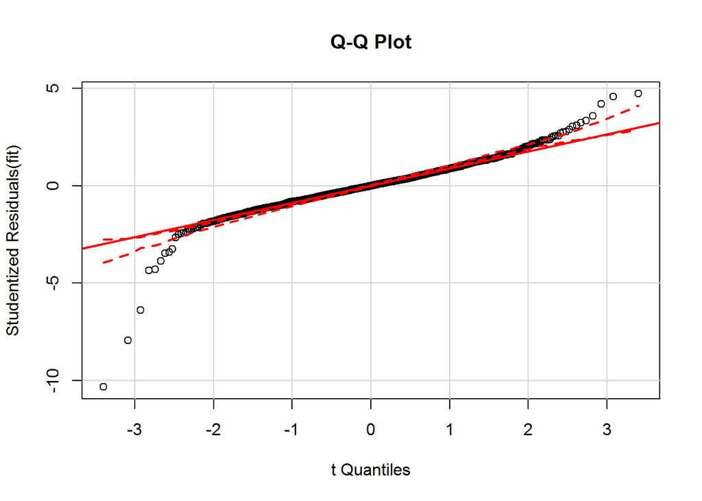

```r
library(car)

#Check normality assumption
qqPlot(fit,label=cars$Price, id.method = "identity",simulate = TRUE, main="Q-Q Plot")
```

On top of plot that you have seem in the Q-Q plot of *plot()* function, *simulate=TRUE* option builds a 95% confidence interval envelope using a parametric bootstrap. *id.method=“identity”* option makes the graph interactive.

You can tell from the graph that while majority of the data point fall close to the straight line and within that envelope, there do have some data points with large positive residuals and negative residuals, which suggest that you need to take a close look at these data.

The following script tests linearity using *car* package:

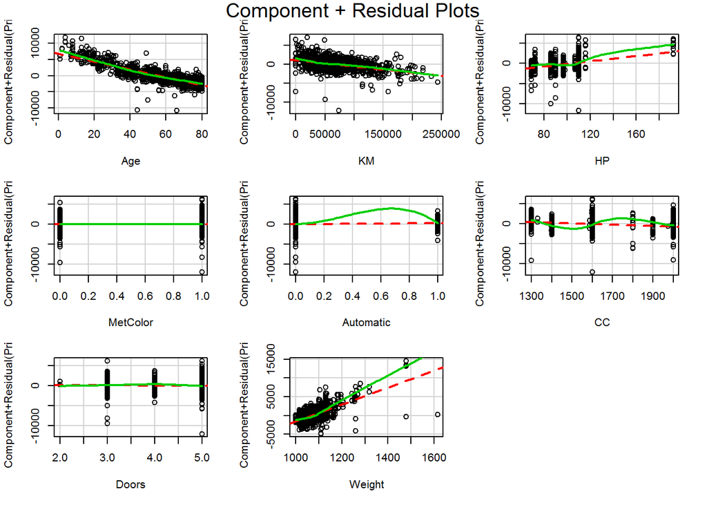

```r
crPlots(fit)
```

There are two functions in *car* package that can be applied to test homoscedasticity.

```r
ncvTest(fit)
```

```
## Non-constant Variance Score Test
## Variance formula: ~ fitted.values
## Chisquare = 409.3105    Df = 1     p = 5.178683e-91
```

This function produces a score test of the hypothesis of constant error variance against the alternative that the error variance changes with the level of fitted values. In this case, the p-value is significant, which suggests heteroscedasticity.

Another function *spreadLevelPlot()* creates a scatter plot of the absolute standardized residuals versus the fitted value and superimposes a line of best fit.

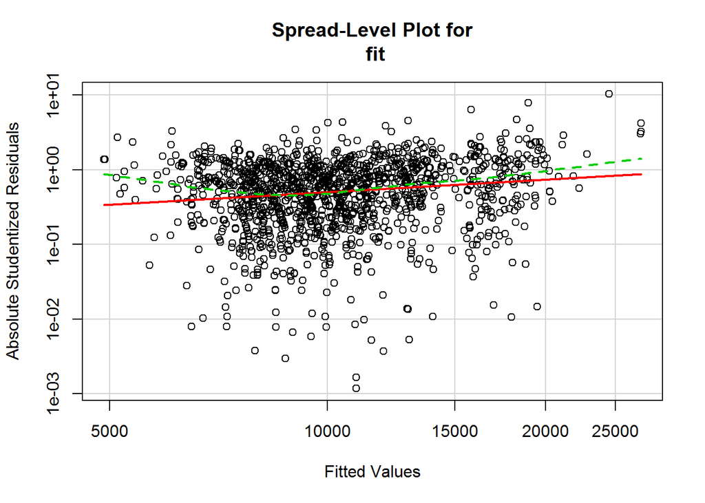

```
##
## Suggested power transformation:  0.442026
```

```r
spreadLevelPlot(fit)
```

From the plot, there seems to be a slight slope of the fitted line. But closer look can tell us why ncvTest function gives significant p-value. Again, this might be due to extreme values at two ends of the data. It suggests that we may consider removing the outliers or look for additional variable.

The Suggested power transformation is 0.442. It means that Price^0.442 might be a better fit than Price. Instead of 0.442, we may just use sqrt(Price).

```r
fit1<-lm(sqrt(Price)~., data=cars)
summary(fit1)
```

```
##
## Call:
## lm(formula = sqrt(Price) ~ ., data = cars)
##
## Residuals:
##     Min      1Q  Median      3Q     Max
## -40.062  -3.455   0.042   3.712  26.368
##
## Coefficients:
##               Estimate Std. Error t value Pr(>|t|)
## (Intercept)  4.896e+01  4.465e+00  10.966  < 2e-16 ***
## Age         -5.643e-01  1.166e-02 -48.406  < 2e-16 ***
## KM          -8.391e-05  5.748e-06 -14.598  < 2e-16 ***
## HP           1.376e-01  1.132e-02  12.156  < 2e-16 ***
## MetColor     1.443e-01  3.374e-01   0.428 0.669048
## Automatic    1.540e+00  6.987e-01   2.204 0.027708 *
## CC          -4.277e-03  1.249e-03  -3.425 0.000633 ***
## Doors        5.786e-02  1.746e-01   0.331 0.740325
## Weight       7.741e-02  4.806e-03  16.105  < 2e-16 ***
## ---
## Signif. codes:  0 '***' 0.001 '**' 0.01 '*' 0.05 '.' 0.1 ' ' 1
##
## Residual standard error: 5.93 on 1427 degrees of freedom
## Multiple R-squared:  0.8651, Adjusted R-squared:  0.8644
## F-statistic:  1144 on 8 and 1427 DF,  p-value: < 2.2e-16
```

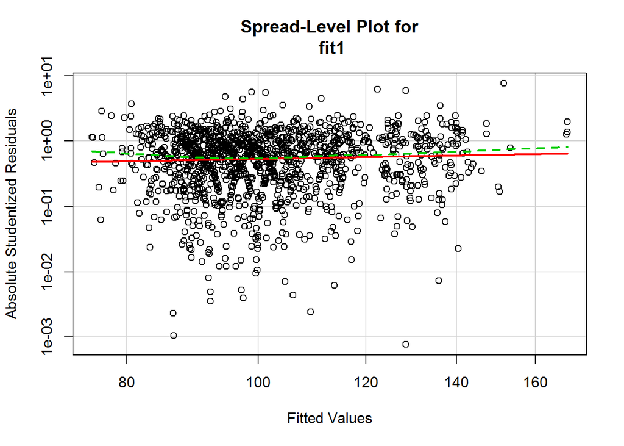

```
##
## Suggested power transformation:  0.6471853
```

```r
spreadLevelPlot(fit1)
```

Although the fit is better, it might be difficult to interpret sqrt(Price) and the fitness does not really improve significantly. Therefore, we may still use the original model.

### Unusual Observations

The following three types of observations are considered unusual:

**Outliers**

The previous analysis suggests that there are outliers in the data. Indeed, points fall out of the confidence band are considered outliers in *qqPlot()* graph. *car* package also provides another dedicated function to detect outliers:

```r
outlierTest(fit)
```

```
##       rstudent unadjusted p-value Bonferonni p
## 222 -10.328200         3.6434e-24   5.2320e-21
## 961  -7.927895         4.4628e-15   6.4086e-12
## 602  -6.390124         2.2393e-10   3.2156e-07
## 148   4.719995         2.5903e-06   3.7197e-03
## 524   4.561801         5.5068e-06   7.9077e-03
## 193  -4.354106         1.4315e-05   2.0556e-02
## 192  -4.296482         1.8528e-05   2.6607e-02
## 110   4.204737         2.7766e-05   3.9872e-02
```

Let’s see what happen if we remove the outliers:

```r
cars.outlier.removed <- cars[c(-222,-961,-602,-148,-524,-193,-192,-110),]

fit.outlier.removed <- lm(Price ~ ., data=cars.outlier.removed)
summary(fit.outlier.removed)
```

```
##
## Call:
## lm(formula = Price ~ ., data = cars.outlier.removed)
##
## Residuals:
##     Min      1Q  Median      3Q     Max
## -6575.4  -763.0   -28.0   701.3  4781.7
##
## Coefficients:
##               Estimate Std. Error t value Pr(>|t|)
## (Intercept) -1.464e+04  1.084e+03 -13.509  < 2e-16 ***
## Age         -1.113e+02  2.440e+00 -45.596  < 2e-16 ***
## KM          -1.658e-02  1.149e-03 -14.429  < 2e-16 ***
## HP           3.123e+01  2.253e+00  13.862  < 2e-16 ***
## MetColor     4.150e+01  6.710e+01   0.618    0.536
## Automatic   -1.054e+02  1.403e+02  -0.752    0.452
## CC          -3.317e+00  2.765e-01 -11.997  < 2e-16 ***
## Doors       -1.575e+02  3.547e+01  -4.440 9.71e-06 ***
## Weight       3.301e+01  1.213e+00  27.206  < 2e-16 ***
## ---
## Signif. codes:  0 '***' 0.001 '**' 0.01 '*' 0.05 '.' 0.1 ' ' 1
##
## Residual standard error: 1176 on 1419 degrees of freedom
## Multiple R-squared:  0.8914, Adjusted R-squared:  0.8908
## F-statistic:  1456 on 8 and 1419 DF,  p-value: < 2.2e-16
```

**High-leverage Points**

Observations that have high leverage leverage are outliers with regard to the other predicators. In other words, they have an unusual combination of predictor values. The response value is not involved in determining leverage.

Observations with high leverage are identified through the *hat statistic*. For a given dataset, the average hat value is *p/n*, where *p* is the number of parameters estimated in the model (including the intercept) and *n* is the sample size. An observation with a hat value greater than 2 or 3 times the average hat value should be examined. You may use the following codes for identifying high-leverage points.

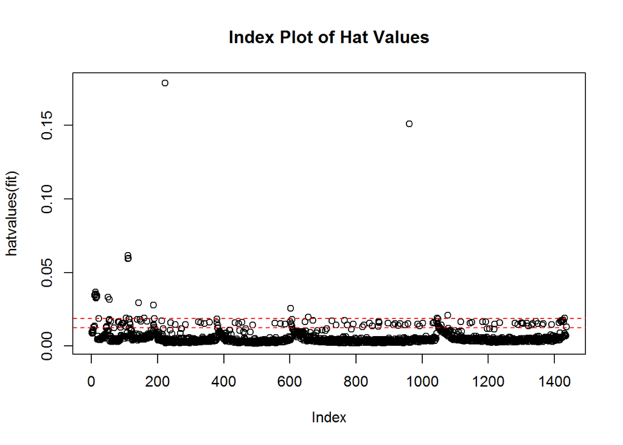

```
## integer(0)
```

```r
hat.plot <- function(fit) {
    p<-length(coefficients(fit))
    n<-length(fitted(fit))
    plot(hatvalues(fit),main="Index Plot of Hat Values")
    abline(h=c(2,3)*p/n,col="red",lty=2)
    identify(1:n,hatvalues(fit),names(hatvalues((fit))))
}
hat.plot(fit)
```

**Influential observations**

*Influential* observations have a disproportionate impact on the values of the model parameters, in other words, with or without these observations change your model significantly. There are two methods for identifying influential observations:

*Cook’s Distance*

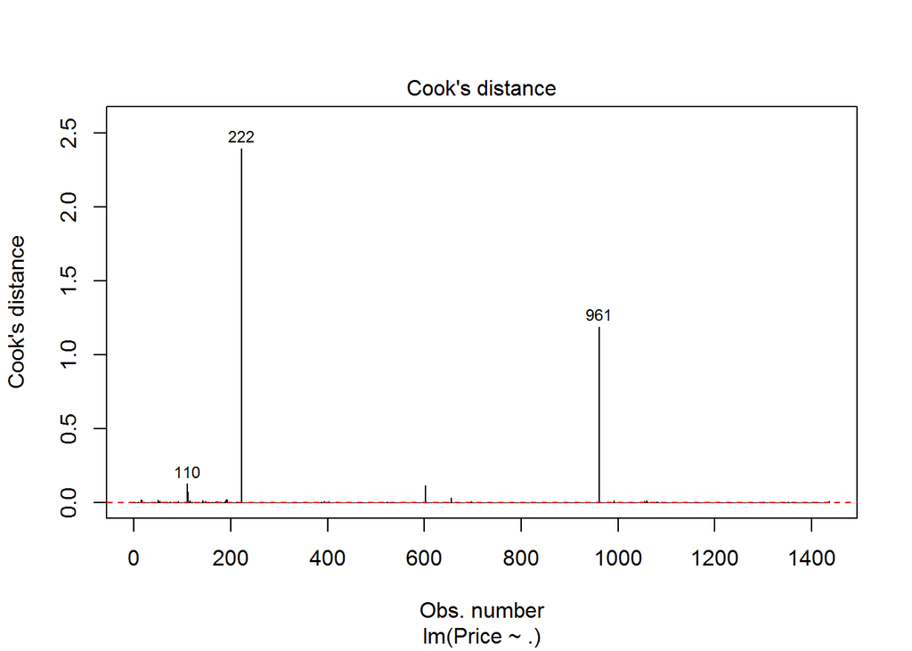

```r
cutoff <- 4/(nrow(cars)-length(fit$coefficients)-2)
plot(fit,which=4,cook.levels = cutoff)
abline(h=cutoff, lty=2,col="red")
```

The graph identifies three influetnial points: records 110, 222, 961.

Cook’s F plots, however, does not provide information on how such observations affect the model. Added-varaible plots can help in this regard.

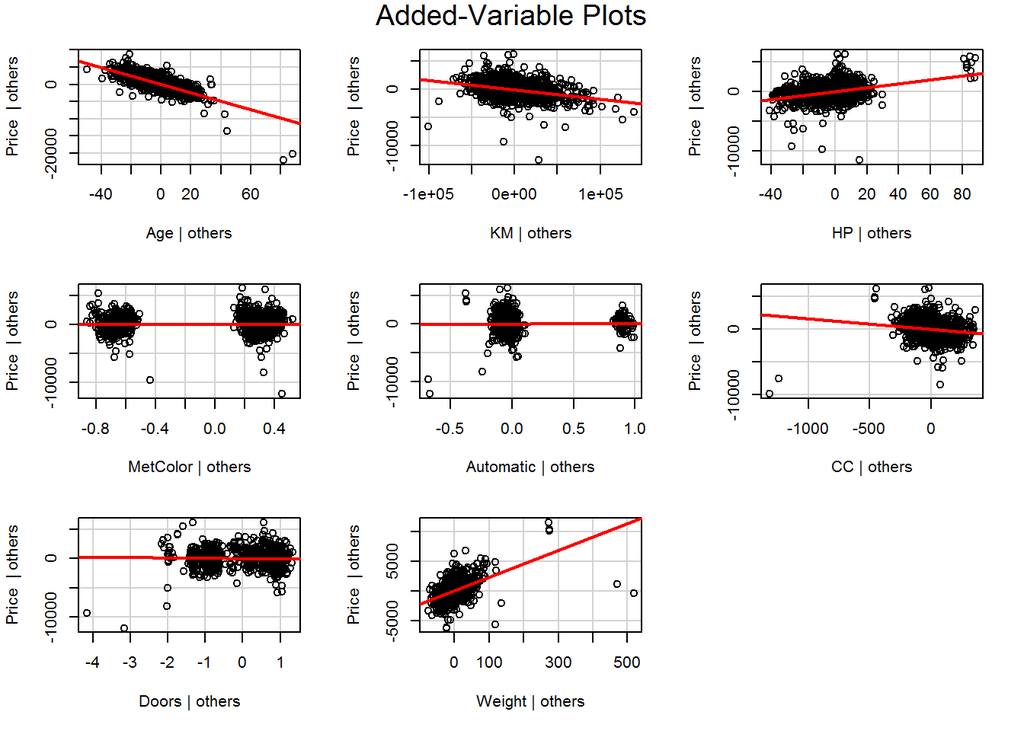

```r
avPlots(fit, ask=FALSE, id.method="identify")
```

You can see from Age | Others plot that if record 222 is removed, the line will be moved in a positive direction.

You can combine all the above three kinds of unusual observations into one plot:

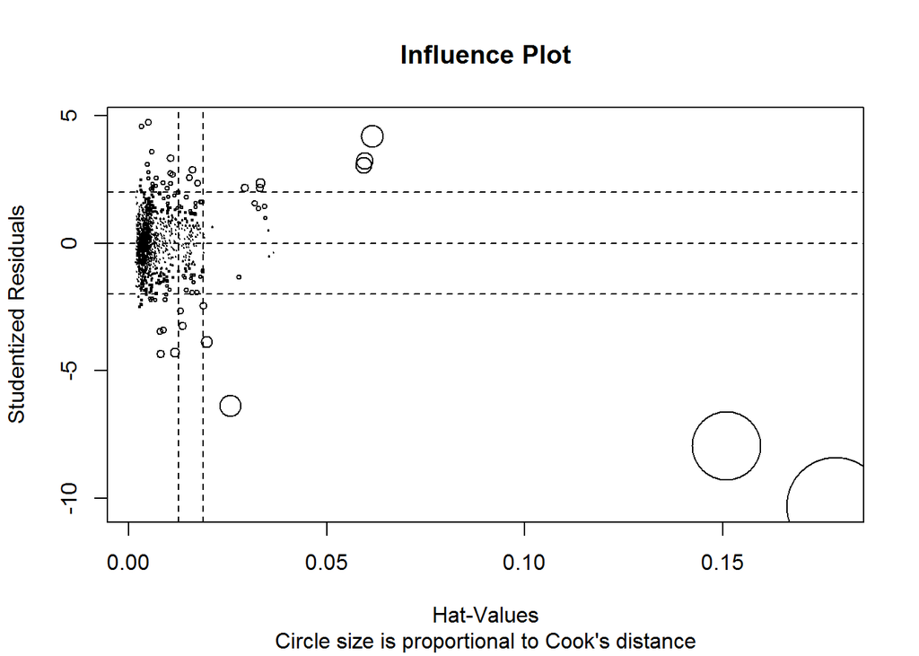

```r
influencePlot(fit, id.method = "identify",main="Influence Plot", sub="Circle size is proportional to Cook's distance")
```